# C. atrox spinal cord bulk RNA-Seq data (gene level) with alignment to C. tigris genome

Jason Gallant[^1]

April 20, 2023

## Methods

### Library preparation

Tissues were dissected from rostral(RSC), medial (MSC), and caudal (CSC) spinal cord from three individual Crotalus atrox (1-3) RNA was isolated from tissues using a Qiagen RNEasy Mini Kit following manufactuer’s instructions. RNA was submitted to MSU RTSF Genomics Core, where Sequencing libraries were prepared using Illumina TruSeq Stranded mRNA Library Preparation Kit. Libraries were QC’d and quantitated using a combination of Qubit dsDNA assay, Caliper LabChipGX and Kapa Illumina Library Quantification qPCR kits. The libraries within each project were pooled for multiplexed sequencing.

### Sequencing

Each pool was loaded on one lane of an Illumina HiSeq 2500 Rapid Run (v2) flow cell to target ~15million paired reads per sample. To reach this target, additional sequencing was performed on a MiSeq using the same read format, and results were pooled.

### Analysis

Raw data was trimmed for adapter sequences and low quality sequences using Trimmomatic v0.38 (Bolger, Lohse, and Usadel 2014) with the following parameters LEADING:5 TRAILING:5 SLIDINGWINDOW:4:5 MINLEN:25. Next, RSEM v1.3.3 (Li and Dewey 2011). was used with the STAR aligner v2.7.3a (Dobin et al. 2012) to align reads to predicted transcripts from the Croatuls tigris genome (NCBI RefSeq GCF_016545835.1) (Margres et al. 2021). Uniquely mapped reads from our samples ranged from 75-79%.

## Results

### Import Data from RSEM

```r
file_names<-list.files('./output_data/rsem_output',pattern="\\genes.results$")
files <- file.path('./output_data/rsem_output', file_names)
names(files) <- str_split_fixed(file_names,"\\.", 2)[,1]

txi.rsem <- tximport(files, type = "rsem", txIn = FALSE, txOut = FALSE)
#head(txi.rsem$counts)
```

```r
tissue_type<-factor(substr(colnames(txi.rsem$counts),2,4))
sampleTable <- data.frame(condition = tissue_type)
rownames(sampleTable) <- colnames(txi.rsem$counts)


zero_length_and_unexpressed = (apply(txi.rsem$abundance, 1, max) == 0) &
                              (apply(txi.rsem$length, 1, min) == 0)

txi.rsem$length = txi.rsem$length[!zero_length_and_unexpressed,]
txi.rsem$abundance = txi.rsem$abundance[!zero_length_and_unexpressed,]
txi.rsem$counts = txi.rsem$counts[!zero_length_and_unexpressed,]

dds <- DESeqDataSetFromTximport(txi.rsem, sampleTable, ~condition)
```

```
## using counts and average transcript lengths from tximport
```

Here we are going to group the medial and rostral as “locomotor” tissue and the caudal as “shaker” tissue.

```r
#keep <- rowSums(counts(dds)) >= 10
#dds <- dds[keep,]
levels(dds$condition)<-c("shaker","medial_locomotor","rostral_locomotor")
dds
```

```
## class: DESeqDataSet
## dim: 22566 9
## metadata(1): version
## assays(2): counts avgTxLength
## rownames(22566): A1CF A4GNT ... ZZEF1 ZZZ3
## rowData names(0):
## colnames(9): 1CSC 1MSC ... 3MSC 3RSC
## colData names(1): condition
```

### Principal Components Analysis

```r
vsdata <- vst(dds, blind=FALSE)
```

```
## using 'avgTxLength' from assays(dds), correcting for library size
```

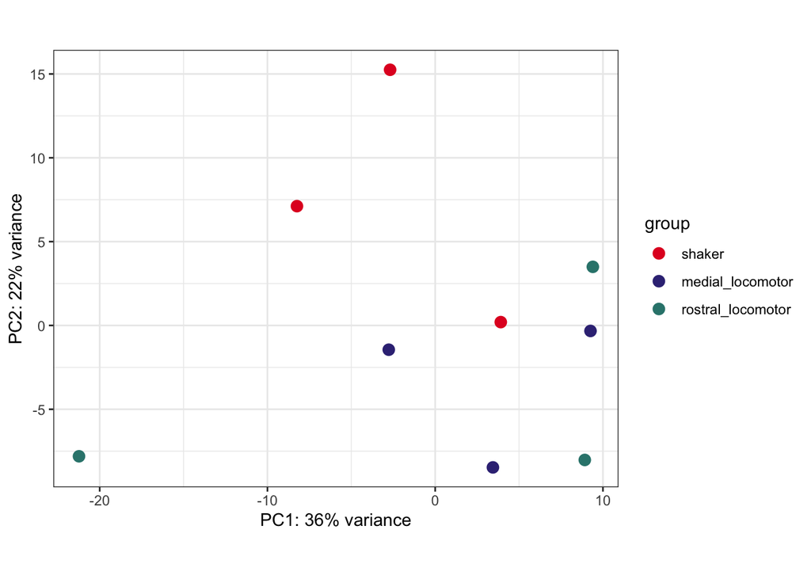

```r
plotPCA(vsdata, intgroup="condition")+scale_color_manual(values=mycolors)
```

I would say that this isn’t impressive clustering, but could represent the overall similarity between these tissue samples. Let’s proceed.

### Differential Expression Analysis

```r
levels(dds$condition)<-c("shaker","locomotor","locomotor")
dds<-DESeq(dds, test="LRT", reduced= ~1)
```

```
## using 'avgTxLength' from assays(dds), correcting for library size
```

```r
res <- results(dds,lfcThreshold = 0, cooksCutoff=T, independentFiltering = T)
head(results(dds, tidy=TRUE))
```

```
##     row     baseMean log2FoldChange     lfcSE          stat    pvalue padj
## 1  A1CF   1.22642202    0.007386088 1.4124747  0.0008955043 0.9761269    1
## 2 A4GNT   0.00000000             NA        NA            NA        NA   NA
## 3  AAAS 121.95193339   -0.015998411 0.2220545  0.0053997509 0.9414218    1
## 4  AACS 724.66166586    0.193569691 0.2302474  0.6970170812 0.4037878    1
## 5 AADAC   0.09869783   -1.138973861 3.5338030 -0.0559707801 1.0000000    1
## 6 AADAT  48.86660041    0.055176219 0.2831033  0.0396125435 0.8422401    1
```

```r
summary(res)
```

```
##
## out of 19118 with nonzero total read count
## adjusted p-value < 0.1
## LFC > 0 (up)       : 0, 0%
## LFC < 0 (down)     : 12, 0.063%
## outliers [1]       : 18, 0.094%
## low counts [2]     : 0, 0%
## (mean count < 0)
## [1] see 'cooksCutoff' argument of ?results
## [2] see 'independentFiltering' argument of ?results
```

Looks like we see 12 genes that are differentially expressed, all up in the shaker samples.

```r
res <- res[order(res$padj),]
subset(res, padj < 0.1)
```

```
## log2 fold change (MLE): condition locomotor vs shaker
## LRT p-value: '~ condition' vs '~ 1'
## DataFrame with 12 rows and 6 columns
##               baseMean log2FoldChange     lfcSE      stat      pvalue
##              <numeric>      <numeric> <numeric> <numeric>   <numeric>
## FST            49.4166       -2.47296  0.414359   38.2229 6.31085e-10
## LRRN4          42.5659       -2.14408  0.358491   38.2025 6.37693e-10
## CREB3L4        29.0225       -1.82259  0.397220   22.3389 2.28535e-06
## HINT2          12.8388       -2.70866  0.642979   19.2102 1.17088e-05
## HOXB13         42.1267       -4.52717  1.020579   19.7797 8.69021e-06
## ...                ...            ...       ...       ...         ...
## HOXA11         9.37233       -3.57126  0.869941   18.3025 1.88463e-05
## ID4          900.12271       -0.56723  0.135699   18.0751 2.12363e-05
## NKX6-1        59.05992       -1.17635  0.293167   16.9062 3.92722e-05
## LOC120319245  20.21182       -1.78262  0.458137   16.0537 6.15696e-05
## MYH7B         58.59445       -2.10151  0.542134   16.2136 5.65859e-05
##                     padj
##                <numeric>
## FST          6.08996e-06
## LRRN4        6.08996e-06
## CREB3L4      1.45500e-02
## HINT2        3.72731e-02
## HOXB13       3.72731e-02
## ...                  ...
## HOXA11         0.0449954
## ID4            0.0450682
## NKX6-1         0.0750099
## LOC120319245   0.0979983
## MYH7B          0.0979983
```

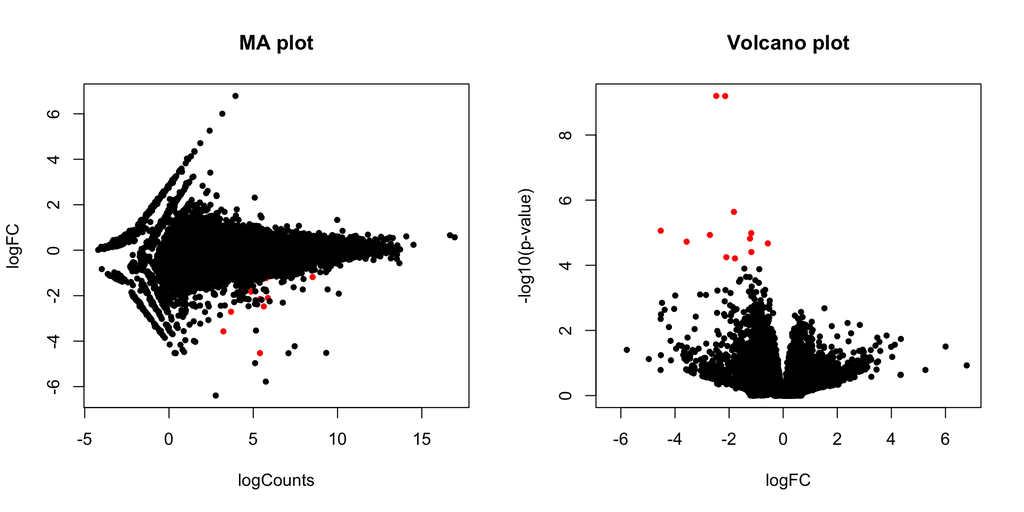

```r
plot_MA = function(logCounts, logFoldChange, FDR, xlab="logCounts", ylab="logFC", title="MA plot", pch=20) {

    plot(logCounts, logFoldChange, col=ifelse(FDR<=0.1, "red", "black"), xlab=xlab, ylab=ylab, main=title, pch=pch);

}


plot_Volcano = function(logFoldChange, pval,FDR, xlab="logFC", ylab="-log10(p-value)", title="Volcano plot", pch=20) {

   plot(logFoldChange, -1*log10(pval), col=ifelse(FDR<=0.1, "red", "black"), xlab=xlab, ylab=ylab, main=title, pch=pch);

}


plot_MA_and_Volcano = function(logCounts, logFoldChange, pval, FDR, xlab="logCounts", ylab="logFC", title="MA plot") {

    def.par = par(no.readonly = TRUE) # save default, for resetting...

    gridlayout = matrix(c(1:2),nrow=1,ncol=2, byrow=TRUE);
    layout(gridlayout, widths=c(1,1,1,1), heights=c(1,1,1,1))

    plot_MA(logCounts, logFoldChange, FDR);
    plot_Volcano(logFoldChange, pval, FDR);

    # draw again, but use a smaller dot for data points
    #plot_MA(logCounts, logFoldChange, FDR, pch='.');
    #plot_Volcano(logFoldChange, FDR, pch='.');


    par(def.par)


}

baseMeanA <- rowMeans(counts(dds, normalized=TRUE)[,colData(dds)$condition == "shaker"])
baseMeanB <- rowMeans(counts(dds, normalized=TRUE)[,colData(dds)$condition == "locomotor"])

trin_res = cbind(baseMeanA, baseMeanB, as.data.frame(res))
trin_res = cbind(id=rownames(trin_res), as.data.frame(trin_res))
trin_res$padj[is.na(trin_res$padj)]  <- 1

plot_MA_and_Volcano(log2(trin_res$baseMean), trin_res$log2FoldChange, trin_res$pvalue,trin_res$padj, 0.1)
```

Let’s look at the DE of the ‘Significant’ Genes at FDR=0.1

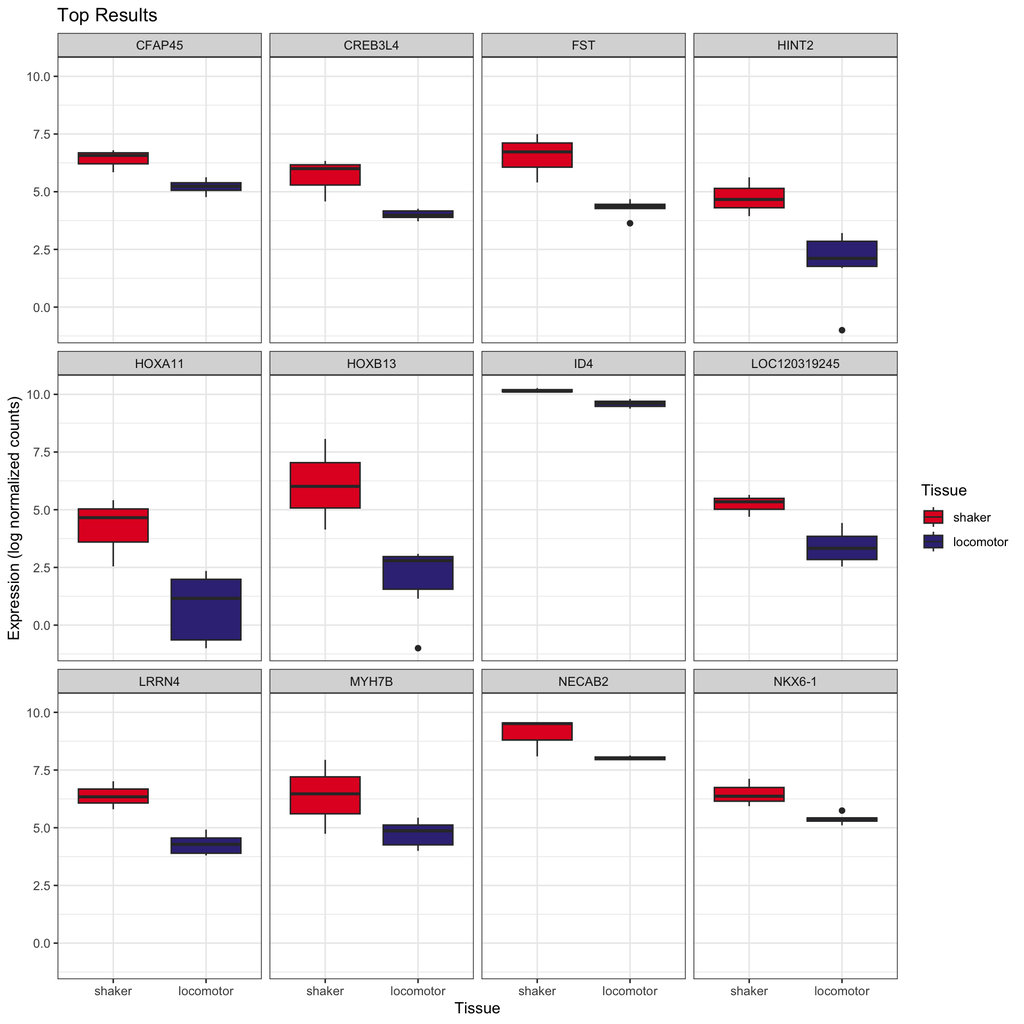

```r
# Define the genes of interest.
goi<-row.names(subset(res, padj < 0.1))
tcounts <- t(log2((counts(dds[goi, ], normalized=TRUE, replaced=FALSE)+.5))) %>%
  merge(colData(dds), ., by="row.names") %>%
  gather(gene, expression, (ncol(.)-length(goi)+1):ncol(.))

ggplot(tcounts, aes(condition, expression, fill=condition)) +
  geom_boxplot() +
  scale_fill_manual(values=mycolors) +
  facet_wrap(~gene) +
  labs(x="Tissue",
       y="Expression (log normalized counts)",
       fill="Tissue",
       title="Top Results")
```

What about genes that we did qPCR on?

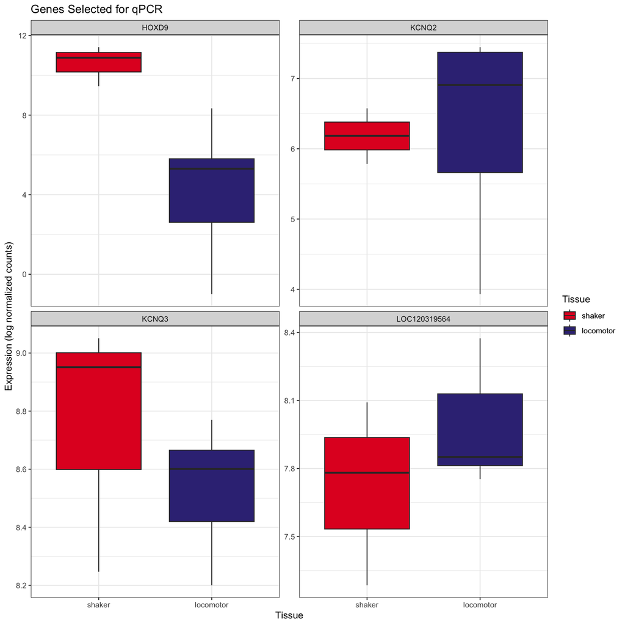

```r
goi<-c("HOXD9","KCNQ3","KCNQ2","LOC120319564")

tcounts <- t(log2((counts(dds[goi, ], normalized=TRUE, replaced=FALSE)+.5))) %>%
  merge(colData(dds), ., by="row.names") %>%
  gather(gene, expression, (ncol(.)-length(goi)+1):ncol(.))

ggplot(tcounts, aes(condition, expression, fill=condition)) +
  geom_boxplot() +
  scale_fill_manual(values=mycolors) +
  facet_wrap(~gene,scales="free_y") +
  labs(x="Tissue",
       y="Expression (log normalized counts)",
       fill="Tissue",
       title="Genes Selected for qPCR")
```

Looks largely consistent with what we saw in qPCR of bulk tissues- HOXD9 (misnamed in earlier analysis) is highly differentially expressed, where KCNQ3 is potentially differentially expressed, though whether this magnitude is meaningful is unclear. KCNQ2 and KCNA1 (here as LOC120319564) are not significant.

What about NALCN?

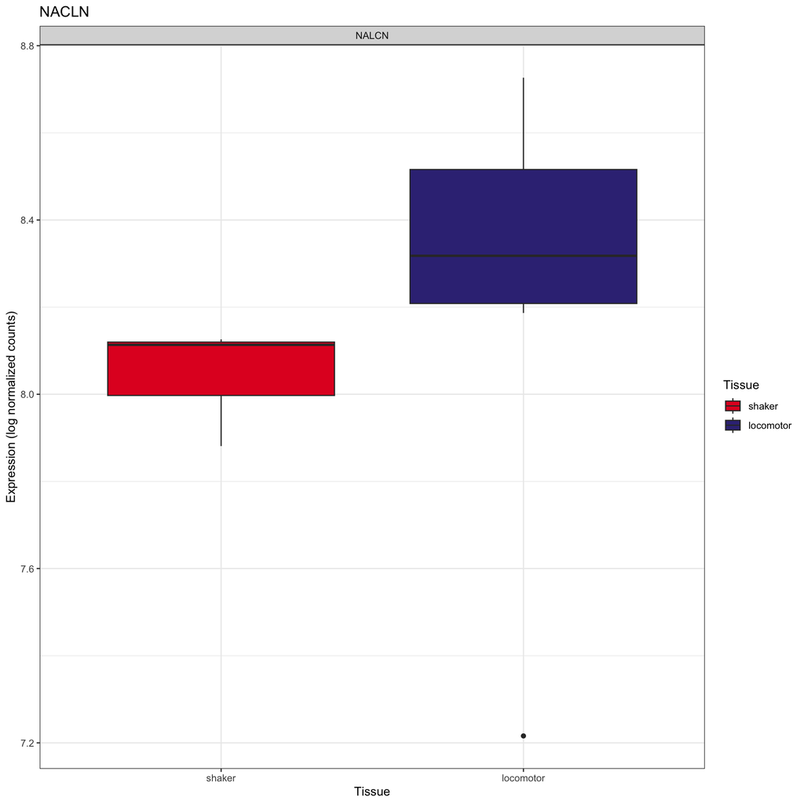

```r
goi<-c("NALCN")

tcounts <- t(log2((counts(dds[goi, ], normalized=TRUE, replaced=FALSE)+.5))) %>%
  merge(colData(dds), ., by="row.names") %>%
  gather(gene, expression, (ncol(.)-length(goi)+1):ncol(.))

ggplot(tcounts, aes(condition, expression, fill=condition)) +
  geom_boxplot() +
  scale_fill_manual(values=mycolors) +
  facet_wrap(~gene,scales="free_y") +
  labs(x="Tissue",
       y="Expression (log normalized counts)",
       fill="Tissue",
       title="NACLN")
```

## References

Benjamini, Yoav, and Yosef Hochberg. 1995. “Controlling the False Discovery Rate: A Practical and Powerful Approach to Multiple Testing.” *Journal of the Royal Statistical Society: Series B (Methodological)* 57 (1): 289–300. https://doi.org/10.1111/j.2517-6161.1995.tb02031.x.

Bolger, Anthony M., Marc Lohse, and Bjoern Usadel. 2014. “Trimmomatic: A Flexible Trimmer for Illumina Sequence Data.” *Bioinformatics* 30 (15): 2114–20. https://doi.org/10.1093/bioinformatics/btu170.

Dobin, Alexander, Carrie A. Davis, Felix Schlesinger, Jorg Drenkow, Chris Zaleski, Sonali Jha, Philippe Batut, Mark Chaisson, and Thomas R. Gingeras. 2012. “STAR: Ultrafast Universal RNA-Seq Aligner.” *Bioinformatics* 29 (1): 15–21. https://doi.org/10.1093/bioinformatics/bts635.

Li, Bo, and Colin N Dewey. 2011. “RSEM: Accurate Transcript Quantification from RNA-Seq Data with or Without a Reference Genome.” *BMC Bioinformatics* 12 (1). https://doi.org/10.1186/1471-2105-12-323.

Love, Michael, Simon Anders, and Wolfgang Huber. 2022. *DESeq2: Differential Gene Expression Analysis Based on the Negative Binomial Distribution*. https://github.com/mikelove/DESeq2.

Love, Michael, Charlotte Soneson, Mark Robinson, Rob Patro, Andrew Parker Morgan, Ryan C. Thompson, Matt Shirley, and Avi Srivastava. 2022. *Tximport: Import and Summarize Transcript-Level Estimates for Transcript- and Gene-Level Analysis*. https://github.com/mikelove/tximport.

Margres, Mark J., Rhett M. Rautsaw, Jason L. Strickland, Andrew J. Mason, Tristan D. Schramer, Erich P. Hofmann, Erin Stiers, et al. 2021. “The Tiger Rattlesnake Genome Reveals a Complex Genotype Underlying a Simple Venom Phenotype.” *Proceedings of the National Academy of Sciences* 118 (4). https://doi.org/10.1073/pnas.2014634118.

[^1]: Michigan State University Department of Integrative Biology, jgallant@msu.edu